# 6. Longitudinal analysis

2023-06-20

> [*Back to content page*](https://flatter11.github.io/6040/)

Learning objective

- Recognize and describe correlations between multiple measurements (Repeated/multiple/longitudinal measures)
- Analyse longitudinal data using generalized estimating equations (GEE)
- Perform model selection for variables and correlation structure for GEE

# 1 Longitudinal analysis

## Background

- Measurements made **repeatedly over time** for each subject
  - Data can be collected retrospectively or prospectively
  - Subjects usually assumed to be **independent** (too complicated if clustered sample over time); Within subjects are **dependent/correlated**
- Another name: ‘panel data’ for sociologists and economists
- Benefits:
  - Provide stronger evidence on the causal effect (time element useful coz causes precedes outcome)
  - Allow observation of change in subjects (get time-dependent variables)
  - Higher power given the same number of subjects (more info in diff time point)
- Cons:
  - More costly (need follow-up)

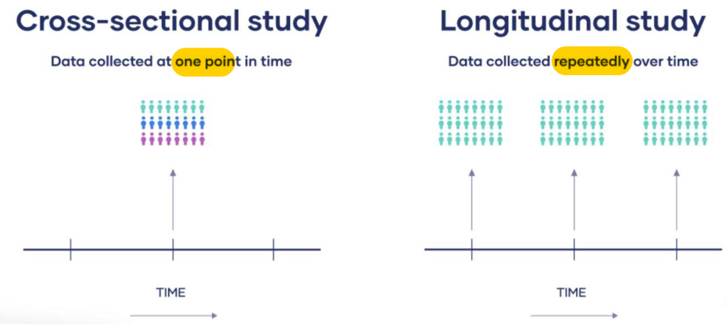

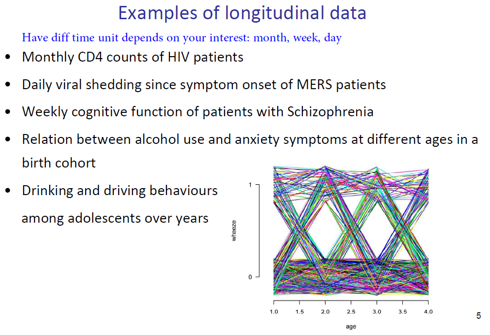

# 2 GEE model

GEE model

- **Marginal model** – response depends on the covariates only (i.e. do not model each level, but model diff levels at the same time and combine them tgt to directly model outcome and covariant)
- It is an **extension of GLM model for correlated or clustered data**
  - It is based on quasi-likelihood but not exact likelihood, so model comparison use QIC instead of AIC
  - Need to specify model/link function/data type (e.g., linear or logistic regression)
  - Need to specify correlation matrix (specify how data is correlated) as nuisance parameter (parameter we r not interested in the value, but need to include in model to account for sth)
- Assumptions
  1. Measurements are independent across subjects
  2. Measurements can dependent/correlated within subjects
  3. Correctly specify model (i.e. link function $g(\mu_i) =x_i^{'}\beta$)

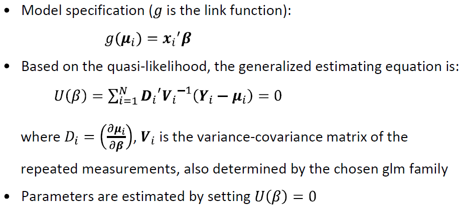

Correlation structure

- Specify how the observations are correlated within subjects
  - **4 Commonly used working correlation structure**: independence, exchangeable, AR(1), unstructured
  - The number of unknown parameters are different for diff structure and are estimated from data
    - e.g. AR(1): 1 unknown parameter
    - e.g. unstructured: 3 unknown parameters for 3 repeated measurements, (k^2-k)/2 =k(k-1)/2 in general

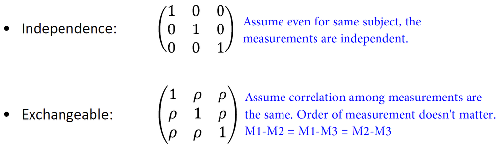

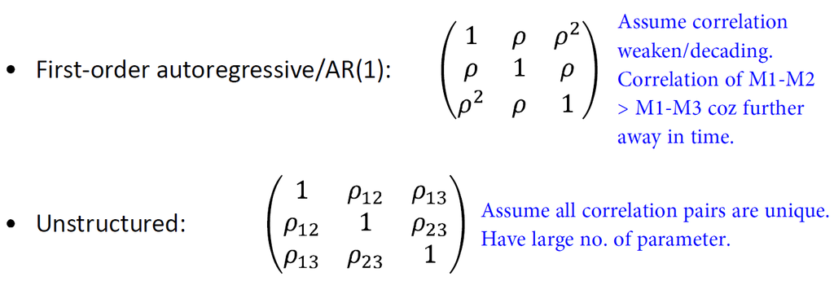

Characteristics of GEE model

- The estimated parameters are **efficient** (i.e. smallest standard error (highest power)) if the correlation structure is **correctly specified**
- The estimated parameters are still **unbiased** even with **misspecification** of the correlation structure
  - However, the standard error will be less accurate (need to increase sample size)
- GEE use a **robust estimator** to do correction on standard error taking that fact that it’s correlated dataset (sandwich estimator, combine SE when it’s IID and SE when it’s correlated)
  - So even we assume independence correlation structure, we still get diff SE compared with GLM.
- Interpretation of estimate depends on **model used**. (same as GLM)
- Handling of missing data
  - Estimates are **valid under MCAR**
  - Model still able to give estimate without imputation, e.g., M1 and M2 without M3 can provide estimate if AR correlation

## Dataset visualization, GLM, residual correlation (R)

- Dataset is about health effect of air pollution
- Dataset is from “geepack” package. Can be loaded via `data(ohio)`
  - Children were followed for four years, with wheeze status recorded annually
  - Also information on age (0 = 9 years, time dependent) and maternal smoking status at the first year of the study (time independent)

```r
library("geepack")
data(ohio)
head(ohio)
summary(ohio)
```

```
##   resp id age smoke
## 1    0  0  -2     0
## 2    0  0  -1     0
## 3    0  0   0     0
## 4    0  0   1     0
## 5    0  1  -2     0
## 6    0  1  -1     0
##       resp              id           age            smoke
##  Min.   :0.0000   Min.   :  0   Min.   :-2.00   Min.   :0.0000
##  1st Qu.:0.0000   1st Qu.:134   1st Qu.:-1.25   1st Qu.:0.0000
##  Median :0.0000   Median :268   Median :-0.50   Median :0.0000
##  Mean   :0.1518   Mean   :268   Mean   :-0.50   Mean   :0.3482
##  3rd Qu.:0.0000   3rd Qu.:402   3rd Qu.: 0.25   3rd Qu.:1.0000
##  Max.   :1.0000   Max.   :536   Max.   : 1.00   Max.   :1.0000
```

Spaghetti plot

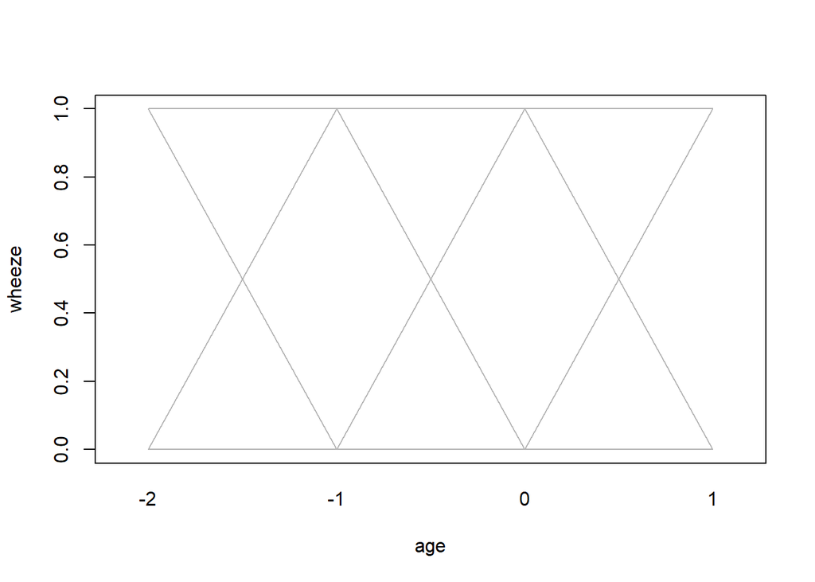

```r
## Spaghetti plot to show temporal trends and corresponding proportions (data visualizations)
with(ohio, interaction.plot(age, id, resp, ylab='wheeze',legend=F, lty=1, col=gray(0.7)))
```

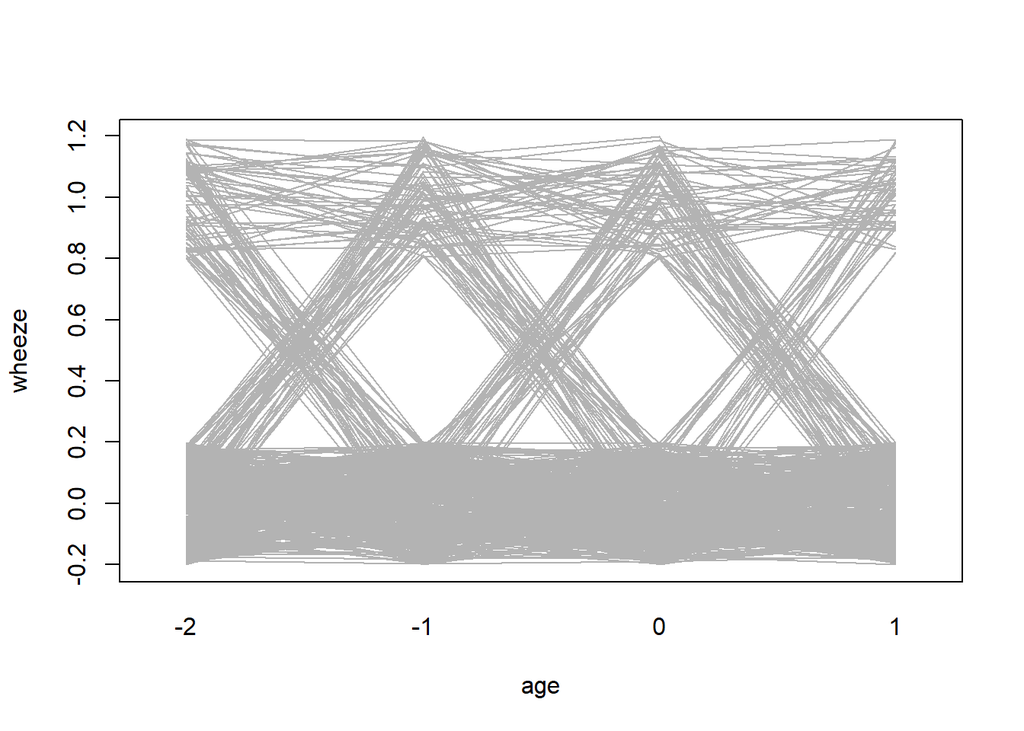

```r
#jitter() to add small voice to avoid overlapping. Without it, can't see the difference between 0 and 1
with(ohio, interaction.plot(age, id, jitter(resp), ylab='wheeze',legend=F, lty=1, col=gray(0.7)))
```

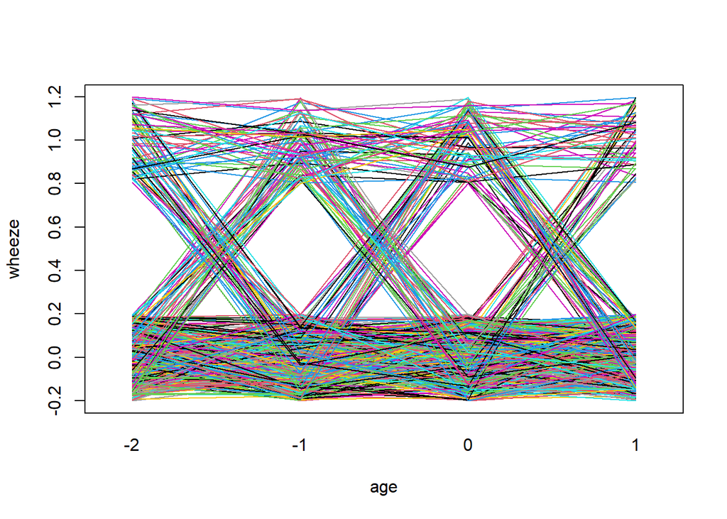

```r
#add colour to see better
with(ohio, interaction.plot(age, id, jitter(resp), ylab='wheeze',legend=F, lty=1, col=sample(1:20, max(id), replace=T)))
```

```r
#have some correlation but not perfect correlation. Line go up and down (exchangeable correlation)
```

GLM model and residual correlation

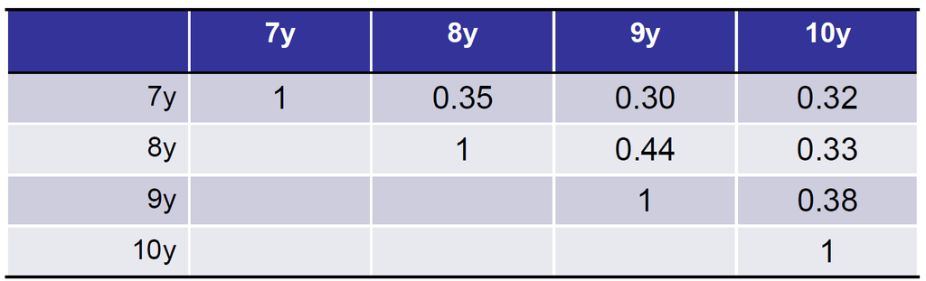

```r
## Fit a GLM model
glm.ohio <- glm(resp~age+smoke, family=binomial, data=ohio)
summary(glm.ohio)
#Age and maternal smoking are both significant at 5% sig. level (p-val = 0.036,0.028)

## Correlation of residuals from the fitted model
cor(glm.ohio$residuals[ohio$age==-2],glm.ohio$residuals[ohio$age==-1])
cor(glm.ohio$residuals[ohio$age==-2],glm.ohio$residuals[ohio$age==0])
cor(glm.ohio$residuals[ohio$age==-2],glm.ohio$residuals[ohio$age==1])

cor(glm.ohio$residuals[ohio$age==-1],glm.ohio$residuals[ohio$age==-0])
cor(glm.ohio$residuals[ohio$age==-1],glm.ohio$residuals[ohio$age==1])

cor(glm.ohio$residuals[ohio$age==0],glm.ohio$residuals[ohio$age==1])
```

```
##
## Call:
## glm(formula = resp ~ age + smoke, family = binomial, data = ohio)
##
## Deviance Residuals:
##     Min       1Q   Median       3Q      Max
## -0.6685  -0.5909  -0.5608  -0.5045   2.0613
##
## Coefficients:
##             Estimate Std. Error z value Pr(>|z|)
## (Intercept) -1.88373    0.08384 -22.467   <2e-16 ***
## age         -0.11341    0.05408  -2.097   0.0360 *
## smoke        0.27214    0.12347   2.204   0.0275 *
## ---
## Signif. codes:  0 '***' 0.001 '**' 0.01 '*' 0.05 '.' 0.1 ' ' 1
##
## (Dispersion parameter for binomial family taken to be 1)
##
##     Null deviance: 1829.1  on 2147  degrees of freedom
## Residual deviance: 1819.9  on 2145  degrees of freedom
## AIC: 1825.9
##
## Number of Fisher Scoring iterations: 4
##
## [1] 0.3506159
## [1] 0.303391
## [1] 0.321748
## [1] 0.43783
## [1] 0.3265596
## [1] 0.3817818
```

## GEE model (R)

- Package: geepack
  - Obtain estimate `geeglm(formula, family, corstr="independence", id, data, subset)`
    - **formula, family, data, subset** same as glm()
    - **corstr**…correlation structure, such as “independence” (by default), “exchangeable”, “ar1”, “unstructure”
    - **id**…identifies the cluster/subject where multiple measurements were made
  - Obtain CI
    - confint() doens’t work for geeglm object
    - `esitcon` to estimate CI linear combination of coefficient (tho we usually only interested in 1 coefficient)
      - linear combination example 0,1,1 = 0*beta0 + 0*beta1 + 1*beta2 (obtain CI of age + smoke
- Comparison between GLM and GEE
  - GLM ignored the dependence between observations, so it will
    - **Overestimate SE of time dependent predictors**  
      GLM thinks between-subject variability was not accounted for GLM assume variability of time-dependent predictors to be randomness that needed to be accounted for, while GEE correctly attribute variation across time to repeated measure
    - **Underestimate SE of time independent predictors**  
      GLM consider multiple measurements as additional independent samples Time independent variable from the same subject is the same in different time points. For example there are 500 subjects measured 4 times, GLM think it’s 2000 while GEE think it’s 500 observations => GLM underestimate SE.

Comparison of estimates

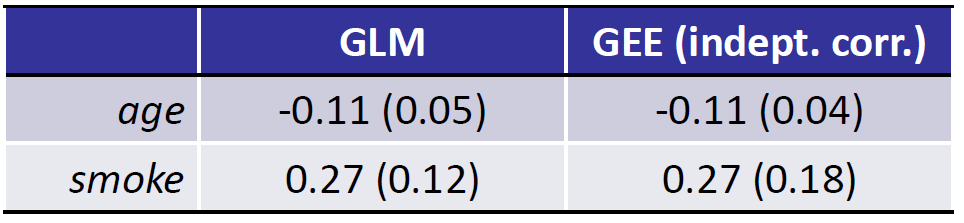

```r
## Fitting GEE model
gee.indp <- geeglm(resp~age+smoke, family=binomial, data=ohio, id=id, corstr = "independence") #Binomial for logistic regression; ID to specify from the same subject
summary(gee.indp)
#Age is still significant but not smoking status

## Obtain estimate and CI
require(doBy)
exp(c(esticon(gee.indp, c(0,0,1))$estimate,esticon(gee.indp,c(0,0,1))$lwr, esticon(gee.indp, c(0,0,1))$upr)) #exp coz its odds ratio; use c to combine as vector; lwr & upr to get lower and upper bound of CI
exp(c(esticon(gee.indp, c(0,1,0))$estimate,esticon(gee.indp,c(0,1,0))$lwr, esticon(gee.indp, c(0,1,0))$upr))
#On average, children with maternal smoking does not have a significantly different risk of wheezing.
#On average, older children (between subjects) / children getting older (within subjects) will have a lower risk of wheezing
#Use "on average" coz GEE didn't estimate individual effect, just population effect
```

```
##
## Call:
## geeglm(formula = resp ~ age + smoke, family = binomial, data = ohio,
##     id = id, corstr = "independence")
##
##  Coefficients:
##             Estimate  Std.err    Wald Pr(>|W|)
## (Intercept) -1.88373  0.11424 271.895  < 2e-16 ***
## age         -0.11341  0.04388   6.681  0.00974 **
## smoke        0.27214  0.17798   2.338  0.12626
## ---
## Signif. codes:  0 '***' 0.001 '**' 0.01 '*' 0.05 '.' 0.1 ' ' 1
##
## Correlation structure = independence
## Estimated Scale Parameters:
##
##             Estimate Std.err
## (Intercept)   0.9991  0.1122
## Number of clusters:   537  Maximum cluster size: 4
## [1] 1.3128 0.9262 1.8607
## [1] 0.8928 0.8192 0.9730
```

## Model comparison (R)

1. Compare **nested models** that differ by the inclusion or exclusion of one or more variables
   - Perform quasi-likelihood ratio test using `anova()`
2. Fit GEE models with exchangeable, AR(1) and unstructured **correlation structure** and compare the results. Under package `MESS`:
   - Quasi-likelihood under the independence model information criterion (QIC) (not AIC coz quasi-likelihood)
   - Can also use correlation information criteriorn (CIC) (BIC before without likelihood)
   - Lower value indicates better model fit
   - Note: it can also be used to select variable

```r
## 1 Nexted models differ in variables
gee.indp0 <- geeglm(resp ~ age, id=id, data=ohio, family=binomial, corstr="independence")
anova(gee.indp, gee.indp0) #model 1 = age+smoke; model 2 = age
```

```
## Analysis of 'Wald statistic' Table
##
## Model 1 resp ~ age + smoke
## Model 2 resp ~ age
##   Df   X2 P(>|Chi|)
## 1  1 2.34      0.13
```

```r
#Maternal smoking is not significant (p-val = 0.13)

## 2a Different correlation structure
gee.exch <- geeglm(resp~age+smoke, family=binomial, data=ohio, id=id, corstr = "exchangeable")
summary(gee.exch)
```

```
##
## Call:
## geeglm(formula = resp ~ age + smoke, family = binomial, data = ohio,
##     id = id, corstr = "exchangeable")
##
##  Coefficients:
##             Estimate Std.err   Wald Pr(>|W|)
## (Intercept)  -1.8804  0.1139 272.60   <2e-16 ***
## age          -0.1134  0.0439   6.68   0.0097 **
## smoke         0.2651  0.1777   2.22   0.1359
## ---
## Signif. codes:  0 '***' 0.001 '**' 0.01 '*' 0.05 '.' 0.1 ' ' 1
##
## Correlation structure = exchangeable
## Estimated Scale Parameters:
##
##             Estimate Std.err
## (Intercept)    0.998   0.112
##   Link = identity
##
## Estimated Correlation Parameters:
##       Estimate Std.err
## alpha    0.354  0.0624
## Number of clusters:   537  Maximum cluster size: 4
```

```r
gee.ar1 <- geeglm(resp~age+smoke, family=binomial, data=ohio, id=id, corstr = "ar1")
summary(gee.ar1) #gives alpha which is the rho (correlation)
```

```
##
## Call:
## geeglm(formula = resp ~ age + smoke, family = binomial, data = ohio,
##     id = id, corstr = "ar1")
##
##  Coefficients:
##             Estimate Std.err   Wald Pr(>|W|)
## (Intercept)  -1.9022  0.1153 272.41   <2e-16 ***
## age          -0.1149  0.0454   6.41    0.011 *
## smoke         0.2345  0.1812   1.67    0.196
## ---
## Signif. codes:  0 '***' 0.001 '**' 0.01 '*' 0.05 '.' 0.1 ' ' 1
##
## Correlation structure = ar1
## Estimated Scale Parameters:
##
##             Estimate Std.err
## (Intercept)     1.02   0.123
##   Link = identity
##
## Estimated Correlation Parameters:
##       Estimate Std.err
## alpha    0.491  0.0673
## Number of clusters:   537  Maximum cluster size: 4
```

```r
gee.unstr <- geeglm(resp~age+smoke, family=binomial, data=ohio, id=id, corstr = "unstructured")
summary(gee.unstr)
```

```
##
## Call:
## geeglm(formula = resp ~ age + smoke, family = binomial, data = ohio,
##     id = id, corstr = "unstructured")
##
##  Coefficients:
##             Estimate Std.err   Wald Pr(>|W|)
## (Intercept)  -1.8886  0.1140 274.64   <2e-16 ***
## age          -0.1149  0.0442   6.75   0.0094 **
## smoke         0.2535  0.1782   2.02   0.1548
## ---
## Signif. codes:  0 '***' 0.001 '**' 0.01 '*' 0.05 '.' 0.1 ' ' 1
##
## Correlation structure = unstructured
## Estimated Scale Parameters:
##
##             Estimate Std.err
## (Intercept)     1.01   0.115
##   Link = identity
##
## Estimated Correlation Parameters:
##           Estimate Std.err
## alpha.1:2    0.350  0.0732
## alpha.1:3    0.308  0.0711
## alpha.1:4    0.303  0.0710
## alpha.2:3    0.470  0.0864
## alpha.2:4    0.319  0.0736
## alpha.3:4    0.376  0.0788
## Number of clusters:   537  Maximum cluster size: 4
```

```r
# Similar results for different correlation structure (robust estimate!! GEE is powerful!!)

## 2b Comparison of correlation structure
require(MESS)
QIC(gee.indp); QIC(gee.exch); QIC(gee.ar1); QIC(gee.unstr)
```

```
##       QIC      QICu Quasi Lik       CIC    params      QICC
##    1829.5    1825.9    -909.9       4.8       3.0    1829.5
```

[output not shown]

```
##       QIC      QICu Quasi Lik       CIC    params      QICC
##   1830.26   1826.27   -910.13      4.99      3.00   1830.27
```

```
##       QIC      QICu Quasi Lik       CIC    params      QICC
##   1829.60   1825.95   -909.97      4.82      3.00   1829.68
```

```r
#All four models are similar. QIC differs less than 1.
```

## Other GEE model (R)

```r
## Model with interaction between maternal smoking and age
gee.int.ar1 <- geeglm(resp~age*smoke, family=binomial, data=ohio,id=id, corstr = "ar1")
summary(gee.int.ar1)
```

```
##
## Call:
## geeglm(formula = resp ~ age * smoke, family = binomial, data = ohio,
##     id = id, corstr = "ar1")
##
##  Coefficients:
##             Estimate Std.err   Wald Pr(>|W|)
## (Intercept)  -1.9248  0.1207 254.31   <2e-16 ***
## age          -0.1478  0.0598   6.10    0.014 *
## smoke         0.2888  0.1914   2.28    0.131
## age:smoke     0.0835  0.0917   0.83    0.362
## ---
## Signif. codes:  0 '***' 0.001 '**' 0.01 '*' 0.05 '.' 0.1 ' ' 1
##
## Correlation structure = ar1
## Estimated Scale Parameters:
##
##             Estimate Std.err
## (Intercept)     1.02   0.125
##   Link = identity
##
## Estimated Correlation Parameters:
##       Estimate Std.err
## alpha    0.491   0.068
## Number of clusters:   537  Maximum cluster size: 4
```

```r
#No significant difference of the age effect across groups (p-val 0.362 across smoking & non-smoking gp)
```

## Missing data (R)

- `waves` option in geeglm can specify the order of the observations

```r
## Create missing dataset
set.seed(111)
n <- nrow(ohio)
n.missing <- 100 #no. of missing data
missing.x <- sample(1:n, n.missing, replace=F) #missing row
missing.y <- sample(c(3,4), n.missing, replace=T) #missing column (3,4 = age, smoke)

ohio.miss <- ohio
ohio.miss$waves = ohio.miss$age + 3 #Create a variable to specify the ordering of the repeated measures (dunno order if we miss age)
ohio.miss[cbind(missing.x, missing.y)] <- NA

## Fit GEE model in missing dataset
gee.ar1.miss <- geeglm(resp~age+smoke, family=binomial, waves=waves, data=na.omit(ohio.miss), id=id, corstr = "ar1") #na.omit to omit missing data
summary(gee.ar1.miss)
#Estimates becomes less significant (e.g. p-val for age change from 0.011 to 0.032)
```

```
##
## Call:
## geeglm(formula = resp ~ age + smoke, family = binomial, data = na.omit(ohio.miss),
##     id = id, waves = waves, corstr = "ar1")
##
##  Coefficients:
##             Estimate Std.err   Wald Pr(>|W|)
## (Intercept)   -1.890   0.117 263.24   <2e-16 ***
## age           -0.101   0.047   4.58    0.032 *
## smoke          0.188   0.184   1.04    0.307
## ---
## Signif. codes:  0 '***' 0.001 '**' 0.01 '*' 0.05 '.' 0.1 ' ' 1
##
## Correlation structure = ar1
## Estimated Scale Parameters:
##
##             Estimate Std.err
## (Intercept)     1.03   0.127
##   Link = identity
##
## Estimated Correlation Parameters:
##       Estimate Std.err
## alpha    0.499  0.0691
## Number of clusters:   537  Maximum cluster size: 4
```

## Model diagnostics

- GEE is an estimating procedure not based on formal likelihood function
  - Standard likelihood-based goodness-of-fit statistics and model diagnostics not applicable
  - Residual plots for assessing the specified mean model  
    In theory, we can compare model-expected mean and observations but it is still difficult so we won’t touch too much on model diagnostics

## GEE modelling strategy

- Need to put **correct variable in the model** instead on focusing on **correlation structure**
  - Modelling of the mean structure most important
- Correlation structure won’t affect result too much, but we can still
  - Use a reasonable correlation structure
    - Can assume independence for the working correlation structure if the expected correlation among repeated measurements is weak
    - Always use the robust estimate for the standard error (i.e. use GEE instead of GLM)
  - Compare the estimates from different assumed correlation structure
  - Can test different correlation structure by QIC

# 3 GLMM model

- Another approach to analyze longitudinal data
- Fit the Ohio data using GLMM (in package lme4)

```r
require(lme4)
ohio.glmm <- glmer(resp~age+smoke+(1|id), family=binomial,data=ohio) #consider id as "cluster/groups"
summary(ohio.glmm)
#Similar results as from GEE
#GLMM estimates have a subject-specific interpretation
```

```
## Generalized linear mixed model fit by maximum likelihood (Laplace
##   Approximation) [glmerMod]
##  Family: binomial  ( logit )
## Formula: resp ~ age + smoke + (1 | id)
##    Data: ohio
##
##      AIC      BIC   logLik deviance df.resid
##     1598     1621     -795     1590     2144
##
## Scaled residuals:
##    Min     1Q Median     3Q    Max
## -1.403 -0.180 -0.158 -0.132  2.518
##
## Random effects:
##  Groups Name        Variance Std.Dev.
##  id     (Intercept) 5.49     2.34
## Number of obs: 2148, groups:  id, 537
##
## Fixed effects:
##             Estimate Std. Error z value Pr(>|z|)
## (Intercept)   -3.374      0.275  -12.27   <2e-16 ***
## age           -0.177      0.068   -2.60   0.0093 **
## smoke          0.415      0.287    1.45   0.1485
## ---
## Signif. codes:  0 '***' 0.001 '**' 0.01 '*' 0.05 '.' 0.1 ' ' 1
##
## Correlation of Fixed Effects:
##       (Intr) age
## age    0.227
## smoke -0.419 -0.010
```

# Review

- GEE estimates the population-averaged effects for longitudinal data (vs individual for random effect model)
- Correlations among repeated measurements as nuisance parameters
- GEE is robust to mis-specification of the variance (or correlation structure)
- Model selection can be done by QIC or quasi-likelihood ratio test
- GLMM can also be used for longitudinal data, but the estimated effects have subject-specific interpretation

# Real-life example

- Effect of expanding medicaid for parents on children’s health insurance coverage lessons from the oregon experiment randomized trial by DeVoe et al. JAMA, Pediatr, 2015
  - Objective: to estimate the effect on a child’s health insurance coverage status when (1) a parent randomly gains access to health insurance and (2) a parent obtains coverage
  - Subjects: 14,409 children in Oregon
  - Outcome: Oregon Health Program (OHP) coverage (assessed monthly) => Use GEE
- Conclusions
  - Children’s odds of having OHP coverage increased when their parents were randomly selected to apply for Medicaid.
  - Children whose parents were selected and subsequently obtained coverage benefited most.

# Conversion of data format (flat vs wide)

- can use `reshape()`

```r
## Changing from 'long' form to 'wide' form
data(ohio)
ohio$ex.age <- ohio$age+9  #existing age in numerical
ohio.w <- reshape(ohio, v.names = c("age","resp"), idvar="id", timevar = "ex.age",
                  direction = "wide")
head(ohio.w)

## Changing from 'wide' form to 'long' form
ohio.l <- reshape(ohio.w, varying = list(c(3,5,7,9),c(4,6,8,10)), v.names = c("age","resp"),
                  idvar="id", times=1:4, direction = "long") #list = columns corresponds to age and resp
ohio.l <- ohio.l[order(ohio.l$id, ohio.l$time),] #reorder by id and time
head(ohio.l)
```

```
##    id smoke age.7 resp.7 age.8 resp.8 age.9 resp.9 age.10 resp.10
## 1   0     0    -2      0    -1      0     0      0      1       0
## 5   1     0    -2      0    -1      0     0      0      1       0
## 9   2     0    -2      0    -1      0     0      0      1       0
## 13  3     0    -2      0    -1      0     0      0      1       0
## 17  4     0    -2      0    -1      0     0      0      1       0
## 21  5     0    -2      0    -1      0     0      0      1       0
##     id smoke time age resp
## 0.1  0     0    1  -2    0
## 0.2  0     0    2  -1    0
## 0.3  0     0    3   0    0
## 0.4  0     0    4   1    0
## 1.1  1     0    1  -2    0
## 1.2  1     0    2  -1    0
```

# 4 Practical (previous exam question)

A study recruited 100 heavy drinkers to participate in an educational program, who were then followed up every three months for 4 times. At each follow-up, the readiness to change (RTC) on alcohol behaviour was assessed through a questionnaire, which was then converted to a score. The number of heavy drinking days (HDD) in the past 30 days was also recorded. Data are stored in the file ‘rtc.csv’, which included:

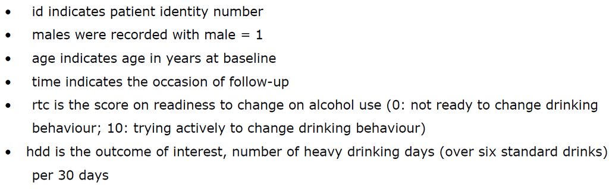

```r
data1 <- read.csv("Data/rtc.csv")
```

## a) Overview of data

1. Give a brief overview of the data including the sample size, age and sex distribution of the subjects, and the pattern of readiness to change score and heavy drinking days.

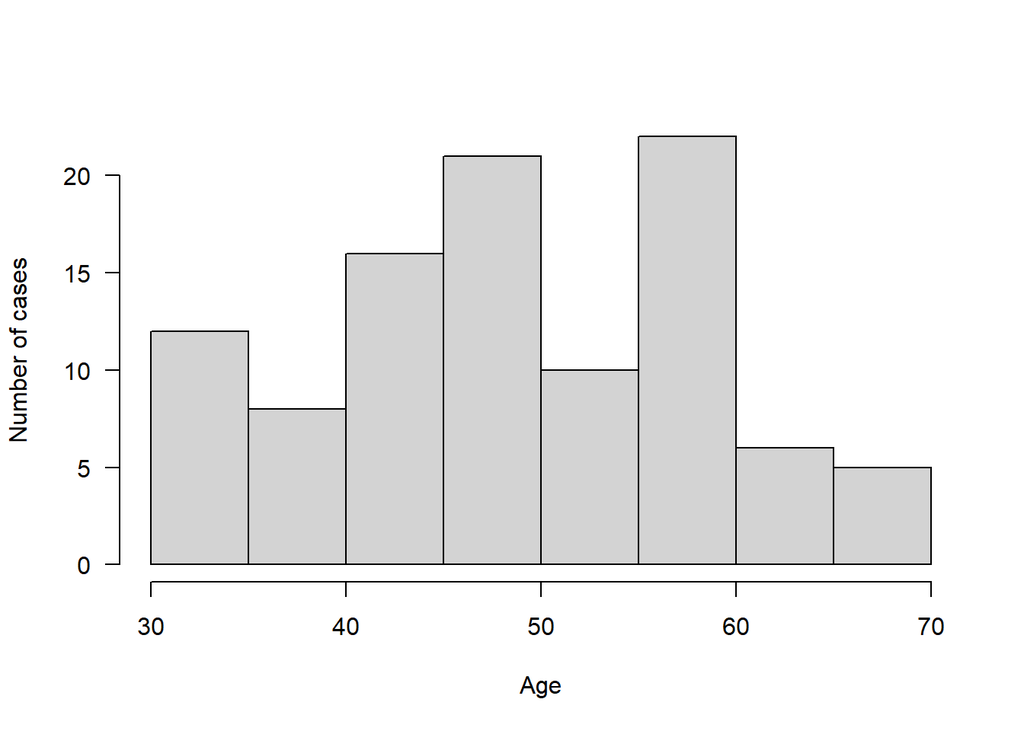

```r
## sample size
length(unique(data1$id)) # N=100
data1.flat <- data1[!duplicated(data1$id),] #get 1 row for each individual
## age (continuous variable)
summary(data1.flat$age) #see min, max, mean etc
hist(data1.flat$age,las=1,xlab="Age",ylab="Number of cases",main=NA) #visualize distribution of age
```

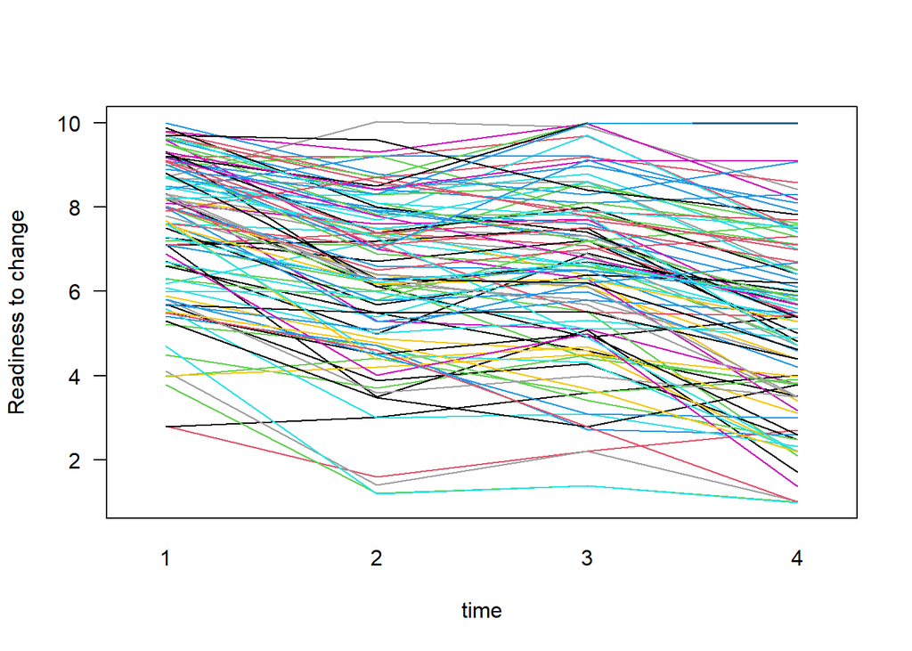

```r
## sex (discrete variable)
table(data1.flat$male) #count of sex
prop.table(table(data1.flat$male)) #prop of sex
## RTC and HDD (spagetti plot for repeated measure)
set.seed(1)
with(data1,interaction.plot(time,id,jitter(rtc),ylab='Readiness to change', legend=F,
                            lty=1, col=sample(1:20, max(id), replace=T),las=1))
```

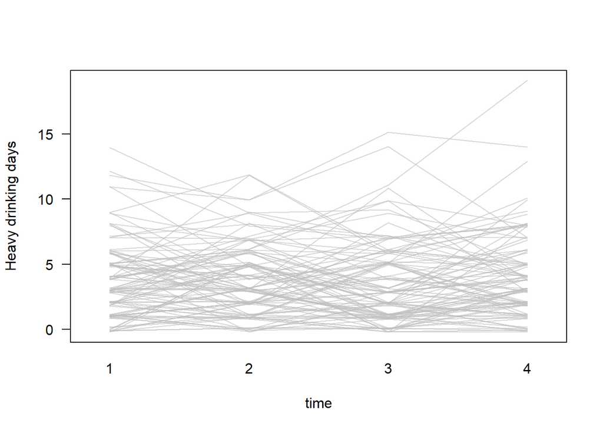

[output not shown]

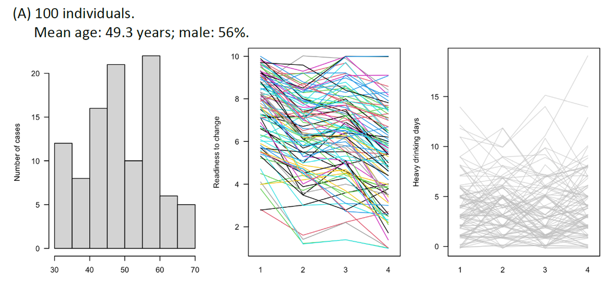

```r
library("ggplot2")
with(data1,interaction.plot(time,id,jitter(hdd),ylab='Heavy drinking days', legend=F,
                            lty=1, col=alpha("gray",0.6),las=1))
```

## b) Fit GEE model

2. Fit appropriate generalized estimating equation models (GEE) to assess the association between RTC and HDD, accounting for potential confounding effect of sex and age. It is expected that HDD at different follow-ups are correlated for the same person. Use at least two different correlation structures for your GEE model and select the best model (Should use log link/poisson family coz outcome is discrete).

```r
gee.indp <- geeglm(hdd~age+male+rtc,data=data1,id=id,
                   family=poisson,corstr = "independence")
gee.exch <- geeglm(hdd~age+male+rtc,data=data1,id=id,
                   family=poisson,corstr = "exchangeable")
gee.ar1 <- geeglm(hdd~age+male+rtc,data=data1,id=id,
                  family=poisson,corstr = "ar1")
gee.unstr <- geeglm(hdd~age+male+rtc,data=data1,id=id,
                    family=poisson,corstr = "unstructured")
QIC(gee.indp); QIC(gee.exch); QIC(gee.ar1); QIC(gee.unstr)
#Choose independence coz lowest QIC
```

```
##       QIC      QICu Quasi Lik       CIC    params      QICC
##  -1207.93  -1216.83    612.42      8.45      4.00  -1207.83
##       QIC      QICu Quasi Lik       CIC    params      QICC
##   -1207.5   -1216.5     612.2       8.5       4.0   -1207.3
##       QIC      QICu Quasi Lik       CIC    params      QICC
##  -1205.06  -1213.96    610.98      8.45      4.00  -1204.91
##       QIC      QICu Quasi Lik       CIC    params      QICC
##  -1206.79  -1215.34    611.67      8.28      4.00  -1206.22
```

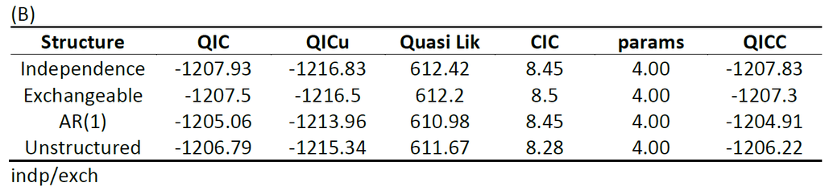

## c) Obtain estimate and CI

3. For the selected model in (B), summarize your results in a table (including the 95% confidence intervals).

```r
summary(gee.indp)

exp(c(esticon(gee.indp, c(0,1,0,0))$estimate,esticon(gee.indp, c(0,1,0,0))$lwr,
      esticon(gee.indp, c(0,1,0,0))$upr)) # age*
exp(c(esticon(gee.indp, c(0,0,1,0))$estimate,esticon(gee.indp, c(0,0,1,0))$lwr,
      esticon(gee.indp, c(0,0,1,0))$upr)) # male
exp(c(esticon(gee.indp, c(0,0,0,1))$estimate,esticon(gee.indp, c(0,0,0,1))$lwr,
      esticon(gee.indp, c(0,0,0,1))$upr)) # rtc*
#Only age and rtc are significant
```

```
##
## Call:
## geeglm(formula = hdd ~ age + male + rtc, family = poisson, data = data1,
##     id = id, corstr = "independence")
##
##  Coefficients:
##             Estimate  Std.err  Wald Pr(>|W|)
## (Intercept)  0.69255  0.30227  5.25    0.022 *
## age          0.02171  0.00513 17.94  2.3e-05 ***
## male         0.21276  0.11412  3.48    0.062 .
## rtc         -0.09001  0.02017 19.92  8.1e-06 ***
## ---
## Signif. codes:  0 '***' 0.001 '**' 0.01 '*' 0.05 '.' 0.1 ' ' 1
##
## Correlation structure = independence
## Estimated Scale Parameters:
##
##             Estimate Std.err
## (Intercept)     1.98   0.173
## Number of clusters:   100  Maximum cluster size: 4
## [1] 1.02 1.01 1.03
## [1] 1.237 0.989 1.547
## [1] 0.914 0.879 0.951
```

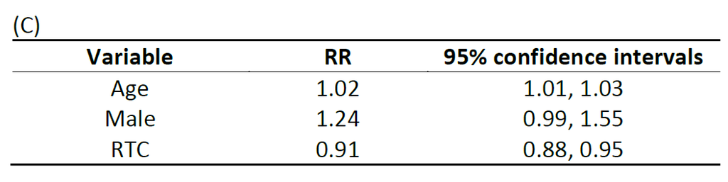